# HW5

2025-04-15

#Problem 1

```r
library(tidyverse)
library(gutenbergr)
library(tm)
library(broom)
library(tidytext)
library(stringr)
library(Matrix)
library(topicmodels)
```

```r
auth <- gutenberg_authors %>%
  filter(str_detect(author, "Stevenson")) %>%
  select(gutenberg_author_id, author)
print(auth)
```

```
## # A tibble: 18 × 2
##    gutenberg_author_id author
##                  <int> <chr>
##  1                  35 Stevenson, Robert Louis
##  2                 334 Stevenson, Fanny Van de Grift
##  3                 980 Stevenson, Burton Egbert
##  4                1908 Stevenson, Sara Yorke
##  5                3576 Stevenson, Augusta
##  6                5161 Stevenson, William
##  7                6177 Stevenson, William G.
##  8                7030 Stevenson, Matilda Coxe
##  9                8196 Stevenson, James
## 10                8814 Prime-Stevenson, Edward
## 11                8858 Stevenson, Adlai E. (Adlai Ewing)
## 12               33528 Forrest, A. S. (Archibald Stevenson)
## 13               40340 Stevenson, Edward Luther
## 14               44788 Stevenson, Robert
## 15               47829 Stevenson, Edward
## 16               48412 Stevenson, David
## 17               48505 Stevenson, William Bennet, active 1803-1825
## 18               52367 Stevenson, Charles Hugh
```

```r
works <- gutenberg_works() %>%
  inner_join(auth, by = "gutenberg_author_id", suffix = c("_work", "_auth"))
print(works %>% select(gutenberg_id, title, author_auth))
```

```
## # A tibble: 97 × 3
##    gutenberg_id title                                                author_auth
##           <int> <chr>                                                <chr>
##  1           42 The Strange Case of Dr. Jekyll and Mr. Hyde          Stevenson,…
##  2          120 Treasure Island                                      Stevenson,…
##  3          136 A Child's Garden of Verses                           Stevenson,…
##  4          280 Records of a Family of Engineers                     Stevenson,…
##  5          281 Father Damien: An Open Letter to the Reverend Dr. H… Stevenson,…
##  6          322 St. Ives: Being the Adventures of a French Prisoner… Stevenson,…
##  7          343 Fables                                               Stevenson,…
##  8          372 Prince Otto, a Romance                               Stevenson,…
##  9          373 Lay Morals, and Other Papers                         Stevenson,…
## 10          380 Weir of Hermiston: An Unfinished Romance             Stevenson,…
## # ℹ 87 more rows
```

```r
texts <- gutenberg_download(works$gutenberg_id, meta_fields = c("title", "author"))
```

```
## Determining mirror for Project Gutenberg from https://www.gutenberg.org/robot/harvest
```

```
## Using mirror http://aleph.gutenberg.org
```

```r
library(tidytext)
tidy_txt <- texts %>%
  mutate(text = as.character(text)) %>%
  unnest_tokens(word, text) %>%
  anti_join(stop_words, by = "word") %>%
  filter(!str_detect(word, "^\\d+$")) %>%
  filter(str_length(word) > 2)
head(tidy_txt, 10)
```

```
## # A tibble: 10 × 4
##    gutenberg_id title                                       author         word
##           <int> <chr>                                       <chr>          <chr>
##  1           42 The Strange Case of Dr. Jekyll and Mr. Hyde Stevenson, Ro… illu…
##  2           42 The Strange Case of Dr. Jekyll and Mr. Hyde Stevenson, Ro… stra…
##  3           42 The Strange Case of Dr. Jekyll and Mr. Hyde Stevenson, Ro… jeky…
##  4           42 The Strange Case of Dr. Jekyll and Mr. Hyde Stevenson, Ro… hyde
##  5           42 The Strange Case of Dr. Jekyll and Mr. Hyde Stevenson, Ro… robe…
##  6           42 The Strange Case of Dr. Jekyll and Mr. Hyde Stevenson, Ro… louis
##  7           42 The Strange Case of Dr. Jekyll and Mr. Hyde Stevenson, Ro… stev…
##  8           42 The Strange Case of Dr. Jekyll and Mr. Hyde Stevenson, Ro… kath…
##  9           42 The Strange Case of Dr. Jekyll and Mr. Hyde Stevenson, Ro… matt…
## 10           42 The Strange Case of Dr. Jekyll and Mr. Hyde Stevenson, Ro… it’s
```

```r
freq <- tidy_txt %>%
  count(title, word, sort = TRUE) %>%
  ungroup()

dtm <- freq %>%
  cast_sparse(title, word, n)
print(dim(dtm))
```

```
## [1]    67 67735
```

```r
print(dtm[1:5, 1:5])
```

[output not shown]

[output cut: 11 more lines]

```r
set.seed(597)
lda_mod <- LDA(dtm, k = 2, control = list(seed = 597))
print(lda_mod)
```

```
## A LDA_VEM topic model with 2 topics.
```

#part a

```r
beta <- tidy(lda_mod, matrix = "beta")

top_words <- beta %>%
  group_by(topic) %>%
  top_n(15, beta) %>%
  arrange(topic, desc(beta))
print(top_words)
```

```
## # A tibble: 30 × 3
## # Groups:   topic [2]
##    topic term       beta
##    <int> <chr>     <dbl>
##  1     1 time    0.00418
##  2     1 day     0.00376
##  3     1 life    0.00367
##  4     1 people  0.00217
##  5     1 house   0.00212
##  6     1 found   0.00210
##  7     1 country 0.00175
##  8     1 sea     0.00169
##  9     1 hand    0.00160
## 10     1 war     0.00152
## # ℹ 20 more rows
```

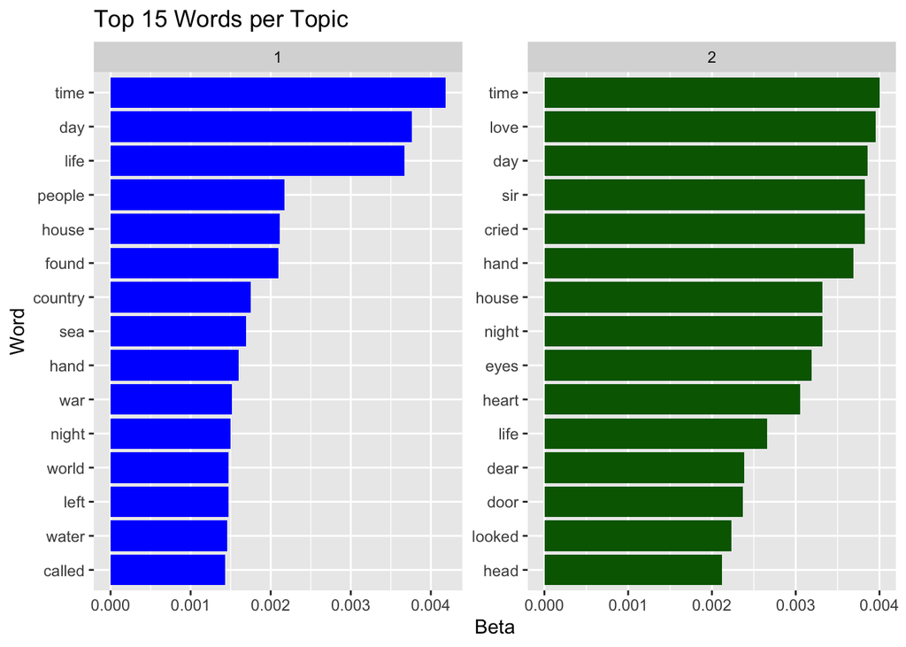

```r
ggplot(top_words, aes(x = reorder_within(term, beta, topic), y = beta, fill = factor(topic))) +
  geom_col(show.legend = FALSE) +
  facet_wrap(~ topic, scales = "free") +
  coord_flip() +
  scale_x_reordered() +
  scale_fill_manual(values = c("1" = "blue", "2" = "darkgreen")) +
  labs(title = "Top 15 Words per Topic", x = "Word", y = "Beta")
```

#part b The LDA analysis, splits stevensons texts into two topics. First one has words like day, life and people foucsing on events and talk more about historical events, second one has words like love, cried and dear which seems to be more personal emtions, feelings and individual experiences. #part c

```r
gamma <- tidy(lda_mod, matrix = "gamma")

doc_max <- gamma %>%
  group_by(document) %>%
  slice_max(gamma, n = 1) %>%
  ungroup() %>%
  filter(gamma >= 0.99)
print(doc_max)
```

```
## # A tibble: 24 × 3
##    document                                                          topic gamma
##    <chr>                                                             <int> <dbl>
##  1 "A Footnote to History: Eight Years of Trouble in Samoa"              1 1.00
##  2 "A Lowden Sabbath Morn"                                               2 1.00
##  3 "American Men of Action"                                              1 1.00
##  4 "American Men of Mind"                                                1 1.00
##  5 "Children's Classics in Dramatic Form, Book Two"                      2 1.00
##  6 "Fables"                                                              2 1.00
##  7 "Illustrated Catalogue of the Collections Obtained from the Indi…     1 1.00
##  8 "Illustrated Catalogue of the Collections Obtained from the Indi…     1 1.00
##  9 "Maximilian in Mexico: A Woman's Reminiscences of the French Int…     1 1.00
## 10 "Records of a Family of Engineers"                                    1 0.999
## # ℹ 14 more rows
```

```r
doc_info <- doc_max %>%
  left_join(works, by = c("document" = "title")) %>%
  select(gutenberg_id, title = document, topic, gamma, author_auth)
print(doc_info)
```

```
## # A tibble: 24 × 5
##    gutenberg_id title                                    topic gamma author_auth
##           <int> <chr>                                    <int> <dbl> <chr>
##  1          536 "A Footnote to History: Eight Years of …     1 1.00  Stevenson,…
##  2        35546 "A Lowden Sabbath Morn"                      2 1.00  Stevenson,…
##  3        16508 "American Men of Action"                     1 1.00  Stevenson,…
##  4        24200 "American Men of Mind"                       1 1.00  Stevenson,…
##  5        16379 "Children's Classics in Dramatic Form, …     2 1.00  Stevenson,…
##  6          343 "Fables"                                     2 1.00  Stevenson,…
##  7        18736 "Illustrated Catalogue of the Collectio…     1 1.00  Stevenson,…
##  8        18703 "Illustrated Catalogue of the Collectio…     1 1.00  Stevenson,…
##  9         5997 "Maximilian in Mexico: A Woman's Remini…     1 1.00  Stevenson,…
## 10          280 "Records of a Family of Engineers"           1 0.999 Stevenson,…
## # ℹ 14 more rows
```

For first topics, the document titles represent historical events and war. for example, A Footnote to History: Eight Years of Trouble in Samoa and American Men of Action. This is what my interpretation in part b suggested. My interpretation is correct for this topics. #Problem 2 #part a

```r
#install.packages("forecast")
library(gapminder)
library(tidyverse)
library(forecast)
```

```r
library(broom)

ma1_res <- gapminder %>%
  group_by(country) %>%
  arrange(year) %>%
  summarize(mod = list(forecast::Arima(lifeExp, order = c(0,0,1))), .groups = "drop") %>%
  mutate(aic = map_dbl(mod, AIC),
         bic = map_dbl(mod, BIC))

print(ma1_res)
```

```
## # A tibble: 142 × 4
##    country     mod          aic   bic
##    <fct>       <list>     <dbl> <dbl>
##  1 Afghanistan <fr_ARIMA>  67.1  68.6
##  2 Albania     <fr_ARIMA>  72.6  74.0
##  3 Algeria     <fr_ARIMA>  83.8  85.2
##  4 Angola      <fr_ARIMA>  62.1  63.5
##  5 Argentina   <fr_ARIMA>  62.3  63.8
##  6 Australia   <fr_ARIMA>  61.9  63.3
##  7 Austria     <fr_ARIMA>  63.2  64.7
##  8 Bahrain     <fr_ARIMA>  78.9  80.4
##  9 Bangladesh  <fr_ARIMA>  80.3  81.8
## 10 Belgium     <fr_ARIMA>  60.4  61.9
## # ℹ 132 more rows
```

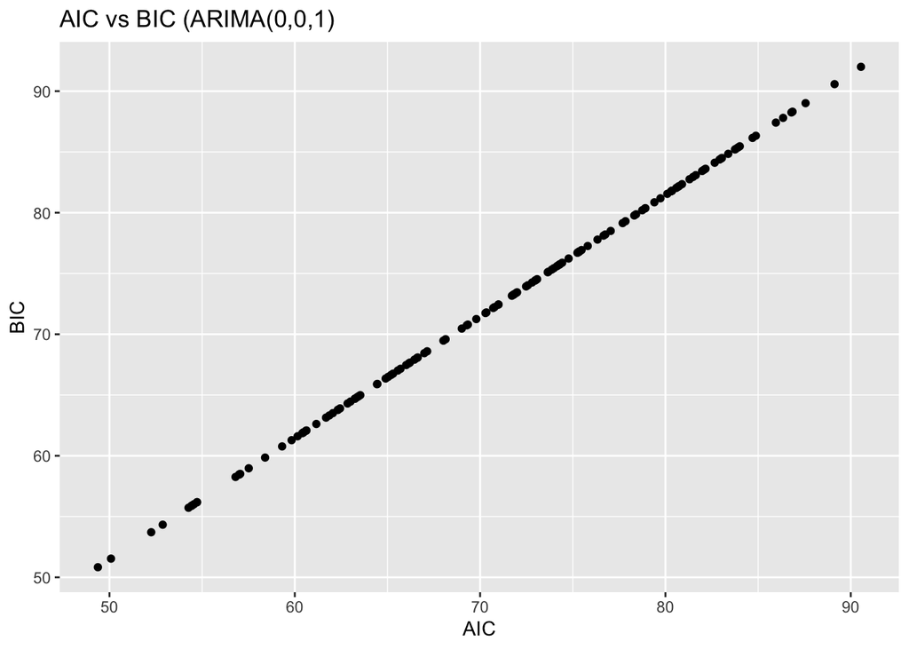

```r
ggplot(ma1_res, aes(x = aic, y = bic)) +
  geom_point() +
  labs(title = "AIC vs BIC (ARIMA(0,0,1)",
       x = "AIC", y = "BIC")
```

The plot shows a positive linear relationship. This means that if AIC values are lower, BIC values will also be lower and vice versa. Both AIC and BIC provide similar relative rankings for the model across countries. #part b

```r
mods <- list(
  "ARIMA(0,0,1)" = c(0,0,1),
  "ARIMA(0,0,2)" = c(0,0,2),
  "ARIMA(0,0,3)" = c(0,0,3),
  "ARIMA(0,1,0)" = c(0,1,0),
  "ARIMA(0,1,1)" = c(0,1,1)
)

mod_comp <- gapminder %>%
  group_by(country) %>%
  arrange(year) %>%
  nest() %>%
  mutate(results = map(data, function(df) {
    map_dfr(names(mods), function(mn) {
      fit <- tryCatch(forecast::Arima(df$lifeExp, order = mods[[mn]]),
                      error = function(e) NA)
      tibble(model = mn, aic = if (is.list(fit)) AIC(fit) else NA_real_)
    })
  })) %>%
  select(-data) %>%
  unnest(results)

print(mod_comp)
```

```
## # A tibble: 710 × 3
## # Groups:   country [142]
##    country     model          aic
##    <fct>       <chr>        <dbl>
##  1 Afghanistan ARIMA(0,0,1)  67.1
##  2 Afghanistan ARIMA(0,0,2)  59.4
##  3 Afghanistan ARIMA(0,0,3)  54.8
##  4 Afghanistan ARIMA(0,1,0)  42.6
##  5 Afghanistan ARIMA(0,1,1)  34.9
##  6 Albania     ARIMA(0,0,1)  72.6
##  7 Albania     ARIMA(0,0,2)  65.6
##  8 Albania     ARIMA(0,0,3)  64.6
##  9 Albania     ARIMA(0,1,0)  53.2
## 10 Albania     ARIMA(0,1,1)  48.1
## # ℹ 700 more rows
```

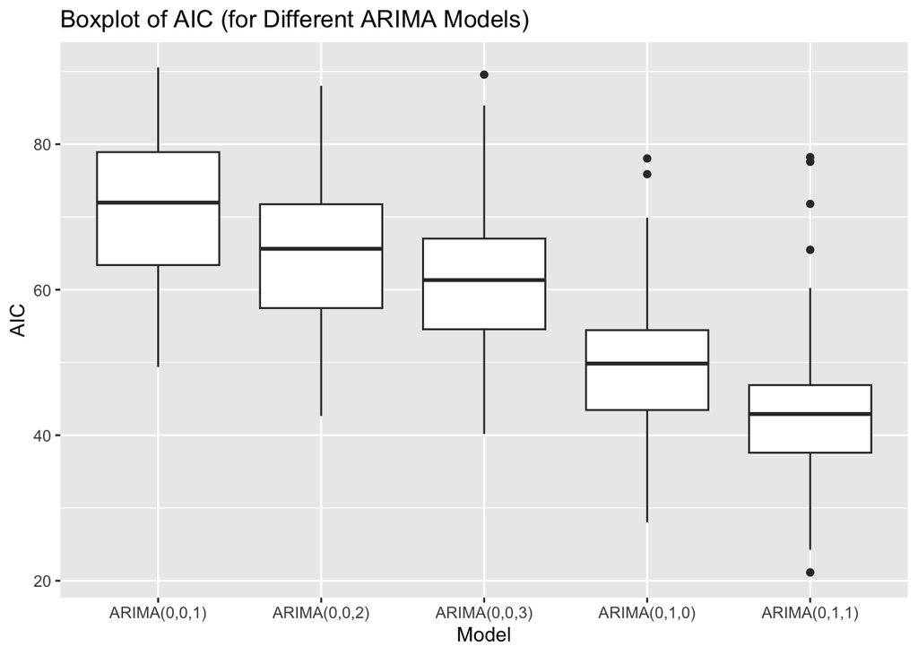

```r
ggplot(mod_comp, aes(x = model, y = aic)) +
  geom_boxplot() +
  labs(title = "Boxplot of AIC (for Different ARIMA Models)",
       x = "Model", y = "AIC")
```

ARIMA(0,1,1) has the lowest AIC scores, so it fits the data best for most countries. #part c

```r
best_mod <- "ARIMA(0,1,1)"

euro_res <- gapminder %>%
  filter(continent == "Europe") %>%
  group_by(country) %>%
  arrange(year) %>%
  nest() %>%
  mutate(
    mod = map(data, ~ tryCatch(forecast::Arima(.x$lifeExp, order = mods[[best_mod]]),
                                error = function(e) NA)),
    tidy_mod = map(mod, ~ if (is.list(.x)) broom::tidy(.x) else tibble())
  ) %>%
  select(country, tidy_mod) %>%
  unnest(tidy_mod)

print(euro_res)
```

```
## # A tibble: 30 × 4
## # Groups:   country [30]
##    country                term  estimate std.error
##    <fct>                  <chr>    <dbl>     <dbl>
##  1 Albania                ma1      1.00      0.353
##  2 Austria                ma1      0.708     0.263
##  3 Belgium                ma1      0.645     0.183
##  4 Bosnia and Herzegovina ma1      1.00      0.353
##  5 Bulgaria               ma1      1.00      0.411
##  6 Croatia                ma1      0.676     0.199
##  7 Czech Republic         ma1      0.606     0.203
##  8 Denmark                ma1      0.494     0.204
##  9 Finland                ma1      0.778     0.227
## 10 France                 ma1      0.706     0.189
## # ℹ 20 more rows
```

#Problem 3 #part a

```r
library(tidyverse)
library(gapminder)
library(broom)
if (!require(ggbeeswarm)) install.packages("ggbeeswarm")
```

```r
library(ggbeeswarm)

models <- gapminder %>%
  group_by(country, continent) %>%
  nest() %>%
  mutate(
    mod = map(data, ~ lm(log10(gdpPercap) ~ year, data = .x)),
    mod_tidy = map(mod, tidy),
    mod_aug = map(mod, augment)
  )
```

#part b

```r
#install.packages('viridis')
library(viridis)
```

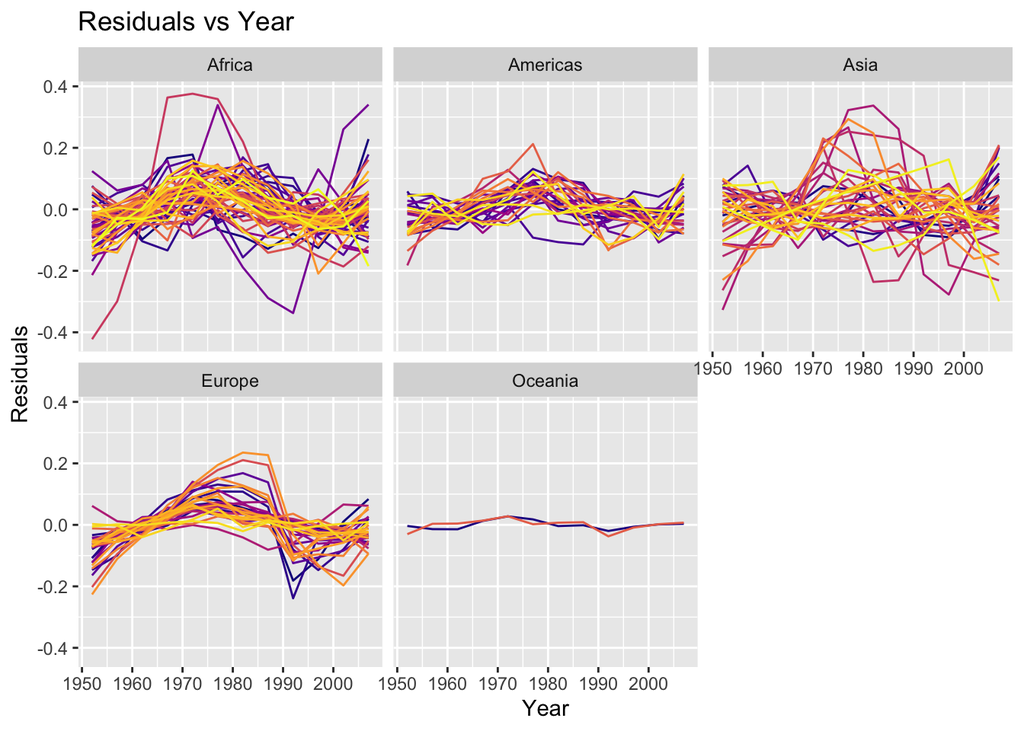

```r
resid_all <- models %>%
  unnest(mod_aug)

ggplot(resid_all, aes(x = year, y = .resid, group = country, color = country)) +
  geom_line(show.legend = FALSE) +
  facet_wrap(~ continent) +
  scale_color_viridis_d(option = "plasma") +
  labs(title = "Residuals vs Year",
       x = "Year", y = "Residuals")
```

#part c

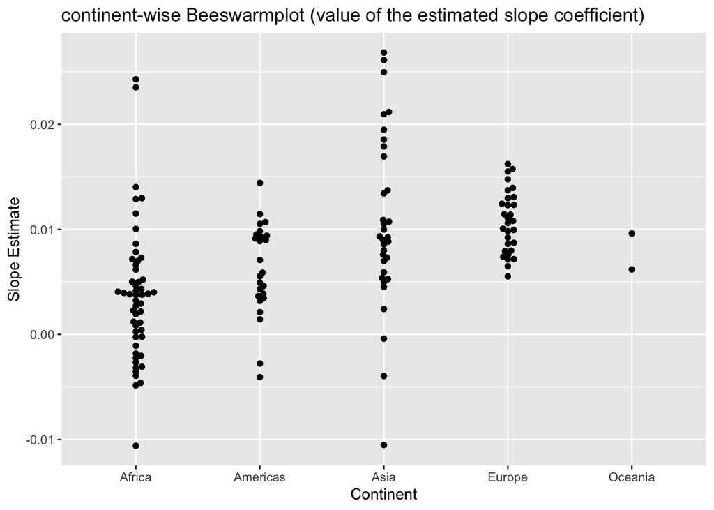

```r
coef_year <- models %>%
  unnest(mod_tidy) %>%
  filter(term == "year") %>%
  mutate(t_stat = estimate / std.error)

ggplot(coef_year, aes(x = continent, y = estimate)) +
  geom_beeswarm() +
  labs(title = "continent-wise Beeswarmplot (value of the estimated slope coefficient)",
       x = "Continent", y = "Slope Estimate")
```